# ARMA Estimation Example

In this notebook we will fit several $AR$, $MA$ and $ARMA$ models to inflation data. Let us begin by pulling CPI inflation data into `R` and taking first differences (we will see that the first differences appear to be more stationary than levels).

```r
library(Ecdat)
data(Mishkin)
inflation = Mishkin[,1]
diffInflation = diff(inflation)
```

To get a sense of the data, let’s plot the time series of inflation and first differences of inflation.

```r
par(mfrow=c(2,1))
plot(inflation, ylab="Inflation rate", main="(a)")
abline(h=0)
```

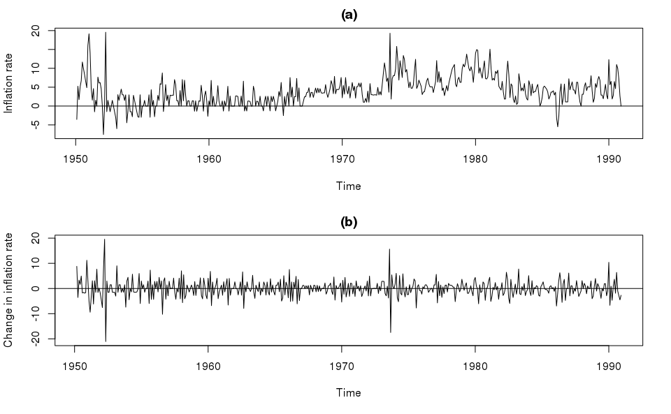

```r
plot(diffInflation, ylab="Change in inflation rate", main="(b)")
abline(h=0)
```

Inflation levels do not appear to have a stationary mean, however the first differences do. The autocorrelations of first differences are depicted below.

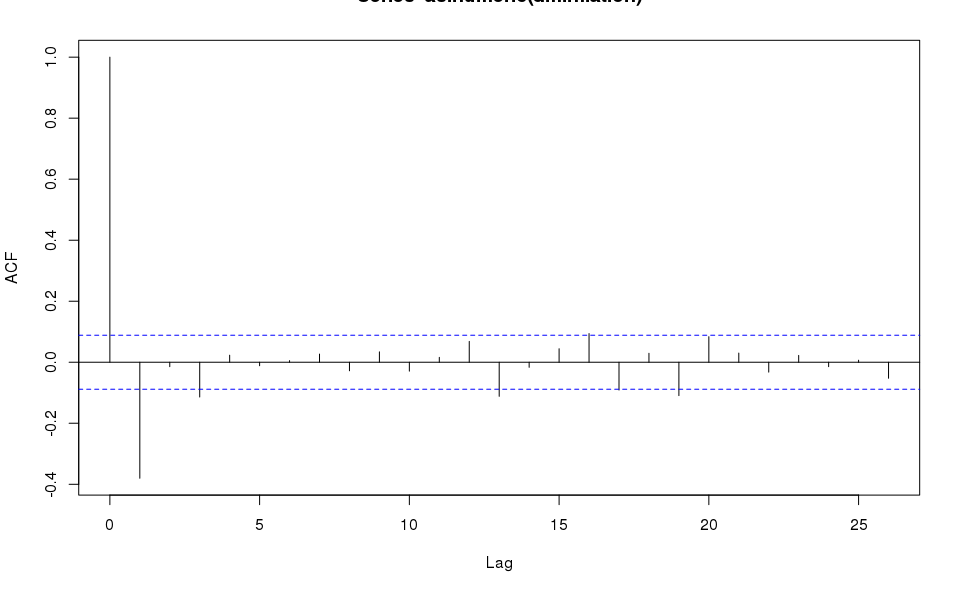

```r
acf(as.numeric(diffInflation))
```

The ACF plot suggests that an $MA(1)$ model might be appropriate for this data. We will begin, however, by fitting an $AR(1)$ and examining the residuals.

```r
ar1Fit = arima(diffInflation, order=c(1,0,0));
layout(matrix(c(1,1,2,3), 2, 2, byrow = TRUE))
plot(ar1Fit$resid)
abline(h=0)
```

```r
acf(as.numeric(ar1Fit$resid))
qqnorm(ar1Fit$resid, datax=TRUE)
```

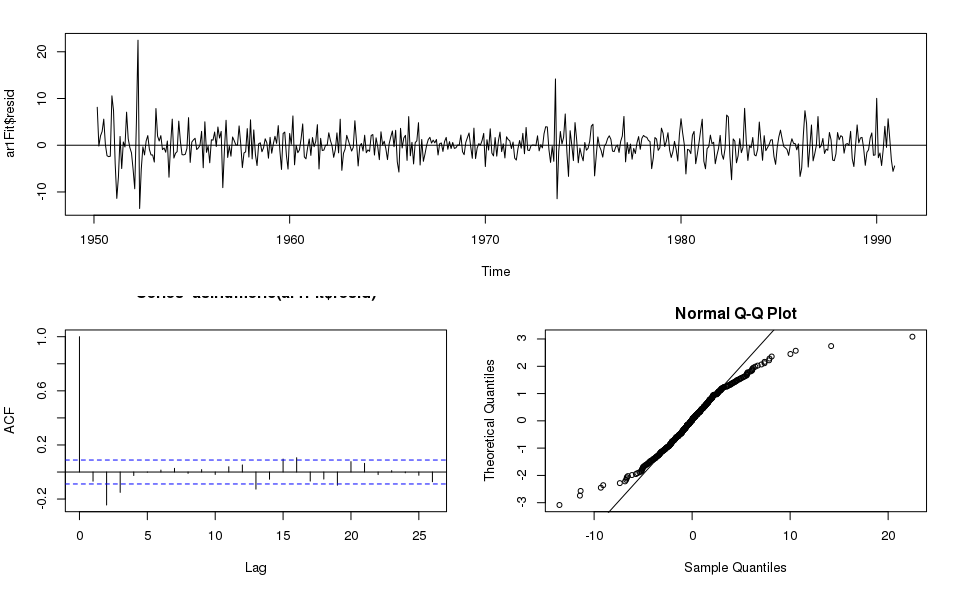

```r
qqline(ar1Fit$resid, datax=TRUE)
```

The time series and ACF plots of the residuals look decent, although the negative autocorrelations at lags 2 and 3 might suggest that we still haven’t appropriately modeled the time dynamics of the data. The next code block fits an $AR(p)$ model for $p = 1,2,\ldots,20$ and plots both the AIC and BIC values for each fit.

```r
#install.packages("forecast"); # run this if 'forecast' not installed
library(forecast)
pMax = 20
aicAR = bicAR = rep(0, length=pMax)
for(p in 1:pMax){
    out = arima(diffInflation, order=c(p,0,0))
    aicAR[p] = out$aic
    bicAR[p] = out$aic - 2*(2+p) + log(length(diffInflation))*(2+p)
}
yMin = min(min(aicAR), min(bicAR))
yMax = max(max(aicAR), max(bicAR))
plot(aicAR, xlab="p", ylab="Criterion", pch=8, ylim=c(yMin,yMax),
    main="AR Fits to Changes in Inflation Rate")
points(bicAR)
```

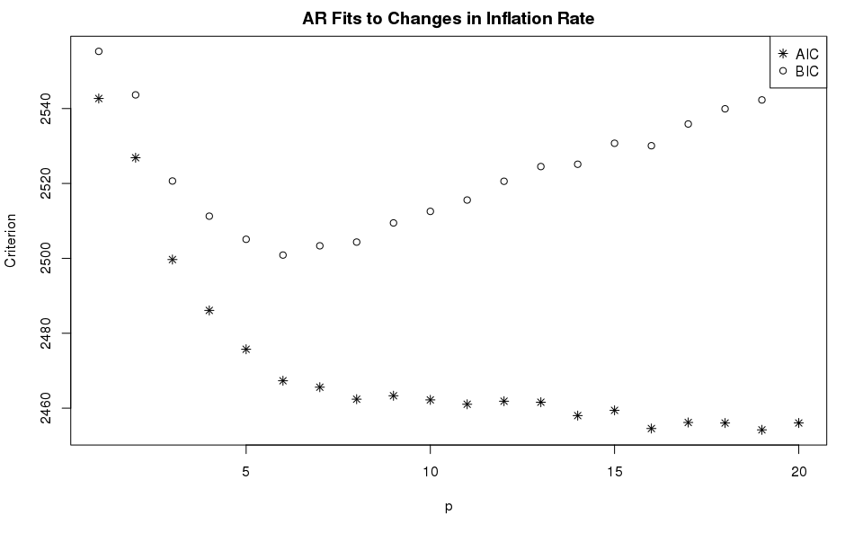

```r
legend("topright", legend=c("AIC", "BIC"), pch=c(8,1))
```

```r
out = auto.arima(diffInflation, max.p=10, max.q=0, ic="bic")
layout(matrix(c(1,1,2,3), 2, 2, byrow = TRUE))
plot(out$resid)
abline(h=0)
```

```r
acf(out$resid)
qqnorm(out$resid, datax=TRUE)
```

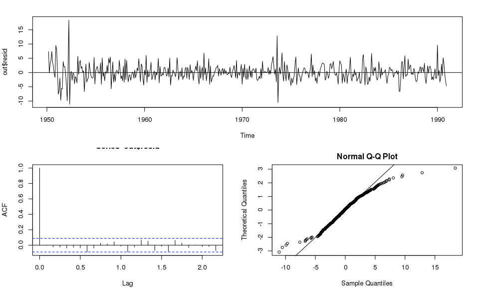

```r
qqline(out$resid, datax=TRUE)
```

The ACF of the residuals looks good. Let’s now repeat the analysis above, fitting an $MA(1)$ and then plotting the AIC and BIC for a sequence of $MA(q)$ models, for $q = 1,2,\ldots,10$.

```r
ma1Fit = arima(diffInflation, order=c(0,0,1))
layout(matrix(c(1,1,2,3), 2, 2, byrow = TRUE))
plot(ma1Fit$resid)
abline(h=0)
```

```r
acf(ma1Fit$resid)
qqnorm(ma1Fit$resid, datax=TRUE)
```

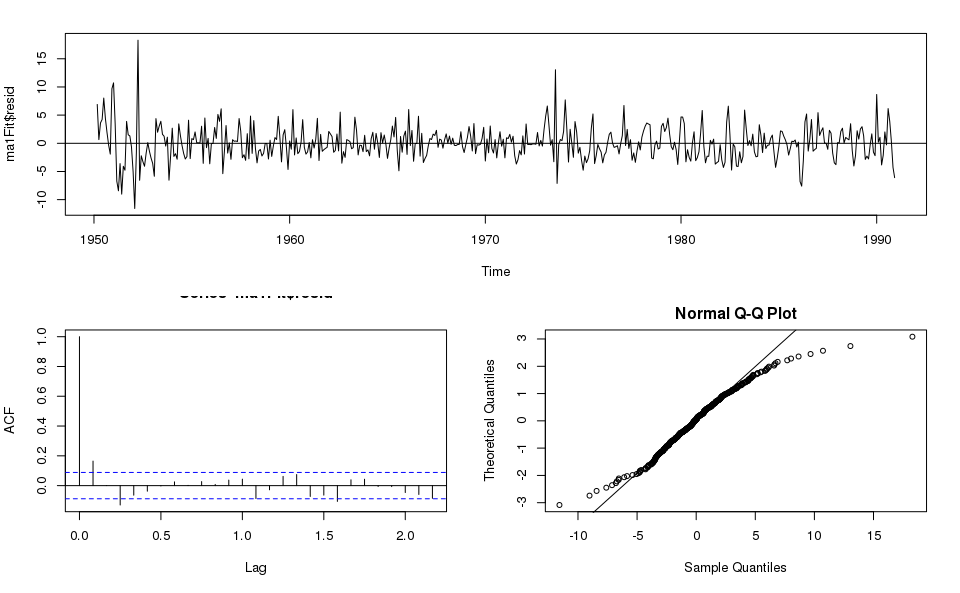

```r
qqline(ma1Fit$resid, datax=TRUE)
```

```r
qMax = 10
aicMA = bicMA = rep(0, length=qMax)
for(q in 1:qMax){
    out = arima(diffInflation, order=c(0,0,q))
    aicMA[q] = out$aic
    bicMA[q] = out$aic - 2*(2+q) + log(length(diffInflation))*(2+q)
}
yMin = min(min(aicMA), min(bicMA))
yMax = max(max(aicMA), max(bicMA))
plot(aicMA, xlab="q", ylab="Criterion", pch=8, ylim=c(yMin,yMax),
    main="MA Fits to Changes in Inflation Rate")
points(bicMA)
```

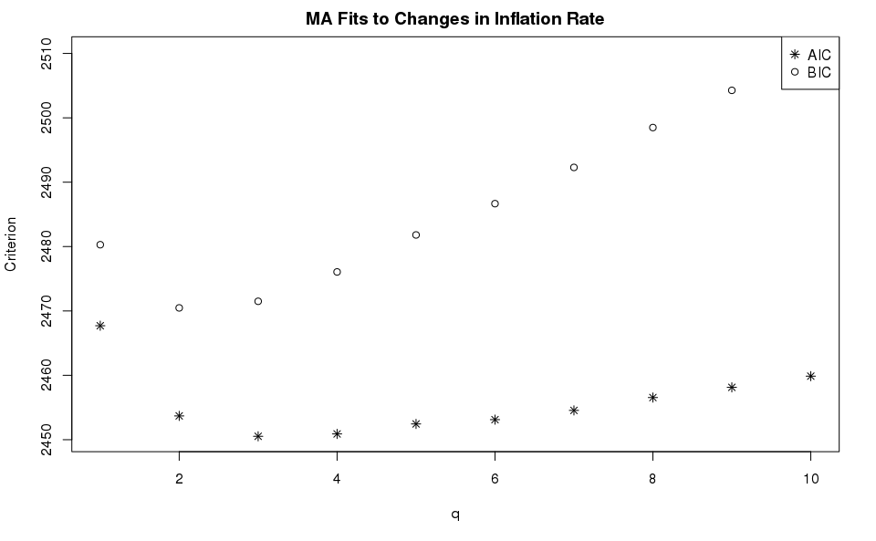

```r
legend("topright", legend=c("AIC", "BIC"), pch=c(8,1))
```

```r
out = auto.arima(diffInflation, max.p=0, max.q=10, ic="bic")
layout(matrix(c(1,1,2,3), 2, 2, byrow = TRUE))
plot(out$resid)
abline(h=0)
```

```r
acf(out$resid)
qqnorm(out$resid, datax=TRUE)
```

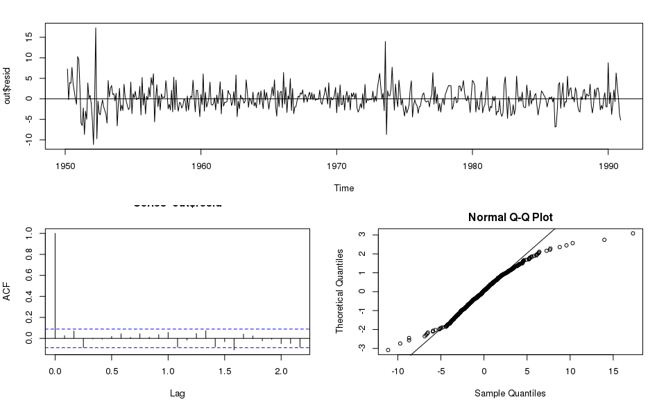

```r
qqline(out$resid, datax=TRUE)
```

Finally, we use the `auto.arima` function to fit a sequence of $ARMA(p,q)$ models for $p=\{1,2,3,4,5\}$ and $q=\{1,2,3,4,5\}$ and examine the residuals of the best fit model.

```r
out = auto.arima(diffInflation, max.p=5, max.q=5, ic="bic")
layout(matrix(c(1,1,2,3), 2, 2, byrow = TRUE))
plot(out$resid)
abline(h=0)
```

```r
acf(out$resid)
qqnorm(out$resid, datax=TRUE)
```

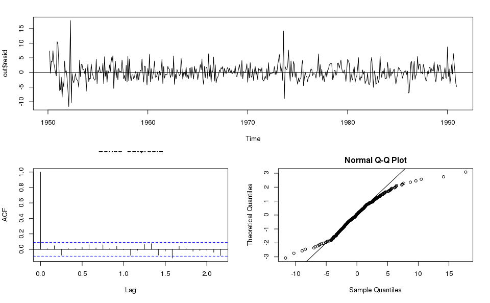

```r
qqline(out$resid, datax=TRUE)
```